# Lecture 2 R Basics

Sep 2, 2020

Robert Settlage

2020-08-22

# Quick review

Rmarkdown let’s us do some cool stuff to weave text and code into a complete description of our work. We can:

*** add a list – syntax for HTML is different than for PDF

*** add an equation
$$\begin{eqnarray}
f(x) & = & x \\
& = & \frac{1}{2}\ast y
\end{eqnarray}$$

*** do some in-line computation

This is 3.1415927

## In-class exercises

*** setup a code chunk – anyone look at options???

```r
########################################################
# (1) sequence
1:10
?seq
x = seq(from = 1, to = 10, by = 2)  # generate a seq.
x.1 = seq(from = 1, to = 100, length.out = 200)
length(x.1)
y = seq(1, 10, 1)

sum(x^2)  # ^ operates on each elemement of x.
y^2

# Extracting a component from a sequence.
x[3]
x[1:3]
x[c(1,4)]

#******* Example 1. Calculate: 1^2+2^2+...+400^2**************
sum((1:400)^2)
sum(seq(from = 1, to = 400, by = 1)^2)

# Example 2. calculate 1*2+2*3+...+249*250
x = seq(1, 249, 1)
y = seq(2, 250, 1)
x*y # componentwise product
sum(x*y)

#**********************************************************
# (2) Vector: an ordered list of numbers/variables
#  In R, a vector is a sequence.

#  Three ways to generate a vector.
#  (1.1) using c(), combination function.
x = c(1, 2, 3)
is.vector(x)

# (1.2)  using seq() to generate a sequence.
x.1 = seq(from = 0, to = 10, length.out =5)
x.2 = seq(0, 10, 2)
class(x.1)  # type of vector: "numeric", "logical", "character"
is.vector(x.1) # find out if x is a vector.

# (1.3)  using rep() to generate vector with repeated numbers.
x.3 = rep(0, times = 10)
x.4 = rep(c(3,1,2), times=2)
x.5 = rep(c(3,1,2), each = 3)

# (1.4) vector operation
(x^2)
2*x
sum(x)
mean(x)
sd(x)
summary(x)
t(x) # transpose.

# length of a vector
x = seq(1,100, by=2)
length(x)

#********************  Example 3. (Numerical Integration.)****
# Int_0^{pi/6} cos(x) dx
# Idea: approximate the integral using Riemann sum (midpoint approximation)

# step 1: partition the range of the integration into n segements.
n.seg = 1000  # this is the total number of segments.
segments = seq(from = 0, to = pi/6, length.out = n.seg + 1)
# this gives n.seg+1 equally spaced segment points
plot(segments, cos(segments), type='l', main='cos(x)')

# step 2. calculate the evaluation point, middle point of each segment.
eval.points = (segments[1:n.seg] + segments[2:(n.seg+1)])/2
View(eval.points)

# step 3. calculate the width of the segments.
del = (pi/6)/n.seg

# step 4. evaluate the function at the evaluation points
f.t = cos(eval.points)

# step 5. calculate the area of each rectangle and sum up.
sum(f.t*del)

#**********************************************************
# (2) matrix.
# two methods to create a matrix.

# (2.1) use function matrix() to transform a vector to a matrix.
vec = c(3, 0, -2, -1, 6,2)
matrix(vec, nrow=2, ncol=3, byrow = FALSE)
matrix(vec, nrow=2, byrow = T)

# (2.2) use functions rbind(), cbind()
row1 = c(3,0,-2)
row2 = c(-1, 6,2)
A = rbind(row1, row2)
cbind(row1, row2)
colnames(A)=c('c1','c2','c3')
A

# (2.3) matrix caculation.
x0 = c(1, 2, -1)
A %*% x0  # A times x0
t(A) # transpose
C= rbind(A, c(-1,-2,3))
diag(C)
 # solve is for matrix inversion.
solve(C)
C^(-1)

# colMeans/rowMeans/rowSums/colSums
A = matrix(1:6, ncol=2, byrow=F)
A
colMeans(A)
colSums(A)
rowMeans(A)
rowSums(A)

# Make a diagonal matrix
B = diag(c(1,2,3))

# dimension of a matrix
dim(B)
dim(B)[1]

# Assign a value to the columns of a matrix
B[,1] = 0.1



#******Example 4.*****************************************
# Solve x1-2 x2 = -1
#       -x1+3 x2= 3

A1 = rbind(c(1, -2), c(-1, 3))
b1 =  c(-1, 3)
solve(A1)%*%b1
#********************************************************
```

OK, together

# In-class exercise:

## Problem 1.

Let A be a 2 by 2 matrix, what is the difference between A%*%A and A^2 in R? ### ANSWER %*% is the operator for matrix math, while A^2 means calculate the square of each element in A.

## Problem 2.

Let A be a 2 by 2, positive definite matrix, what is the difference between A^(-1) and solve(A) in R? ### ANSWER Same as problem 1, solve is a matrix operation while A^(-1) gives 1/a[i,j]

## Problem 3.

Using the Riemann sum idea to numerically evaluate $\int_0^1 x^3 dx$.

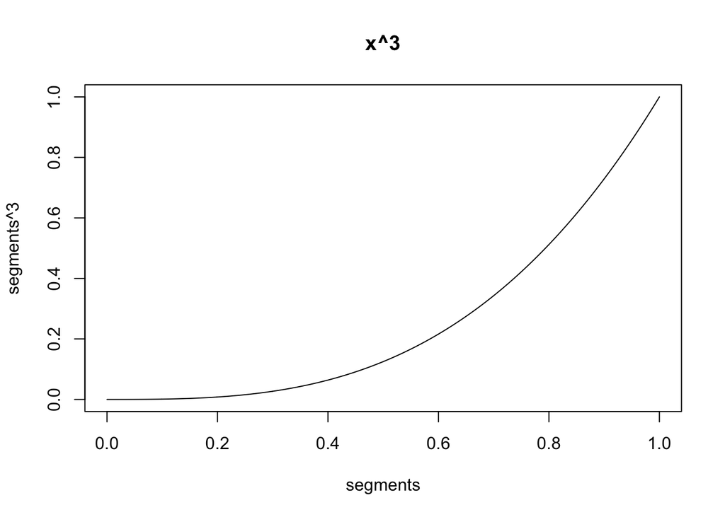

```r
# step 1: partition the range of the integration into n segements.
n.seg = 1000  # this is the total number of segments.
segments = seq(from = 0, to = 1, length.out = n.seg + 1)
# this gives n.seg+1 equally spaced segment points
plot(segments, segments^3, type='l', main='x^3')
```

```r
# step 2. calculate the evaluation point, middle point of each segment.
eval.points = (segments[1:n.seg] + segments[2:(n.seg+1)])/2
# step 3. calculate the width of the segments.
del = (1-0)/n.seg
# step 4. evaluate the function at the evaluation points
f.t = eval.points^3
# step 5. calculate the area of each rectangle and sum up.
total2<-sum(f.t*del)
```

## Problem 4.

Solve the linear system using R
$$\begin{eqnarray}
x -3y +3z = -4 \\
2 x + 3y -z = 15 \\
4 x- 3y -z = 19
\end{eqnarray}$$

```r
# thinking of this as Ax=b
A <- matrix(c(1,-3,3,2,3,-1,4,-3,-1), byrow = T, nrow = 3)
b <- c(-4,15,19)
x <- solve(A)%*%b
# always check your work
A%*%x
```

## Problem 5.

This is about data wrangling. Basically, all we are doing is column/row exercises on a dataset to change its shape. There are some swirl exercises that will drive this home.

Let’s end this with a quick look at the homework.